# Archivo RMD_ Modulo 8

Ana Dos Santos

2024-07-17

## 0.1 Configuración del documento

## 0.2 Instalación si se requiere y carga de paquetes

[output not shown]

[output cut: 28 more lines]

[output not shown]

## 0.3 Carga de BBDD

```
## # A tibble: 6 × 33
##   name  essround edition proddate  idno dweight pspwght pweight anweight    prob
##   <chr>    <dbl>   <dbl> <chr>    <dbl>   <dbl>   <dbl>   <dbl>    <dbl>   <dbl>
## 1 ESS9…        9     3.2 23.11.2…    27   0.581   0.218   0.302   0.0659 1.18e-3
## 2 ESS9…        9     3.2 23.11.2…   137   1.06    0.413   0.302   0.125  6.43e-4
## 3 ESS9…        9     3.2 23.11.2…   194   1.38    2.27    0.302   0.686  4.96e-4
## 4 ESS9…        9     3.2 23.11.2…   208   0.993   0.386   0.302   0.117  6.88e-4
## 5 ESS9…        9     3.2 23.11.2…   220   0.377   1.03    0.302   0.312  1.81e-3
## 6 ESS9…        9     3.2 23.11.2…   254   1.48    0.576   0.302   0.174  4.62e-4
## # ℹ 23 more variables: stratum <dbl>, psu <dbl>, aesfdrk <dbl>, crmvct <dbl>,
## #   Edad <dbl>, `Tiempo de uso de Internet` <dbl>,
## #   `Años de educación a tiempo completo` <dbl>,
## #   `Satisfacción con la economía` <dbl>,
## #   `Satisfacción con la educación` <dbl>,
## #   `Satisfacción con el gobierno` <dbl>, `Satisfacción con la vida` <dbl>,
## #   `Nivel de felicidad` <dbl>, `Salud subjetiva` <dbl>, …
```

## 0.4 Gráficos Satisfacción y Felicidad

Se van a generar los siguientes gráficos: 1. Distribución de la Felicidad 2. Distribución de la Satisfacción con la vida 3. Distribución de la Salud Subjetiva

**Distribución de la Felicidad**

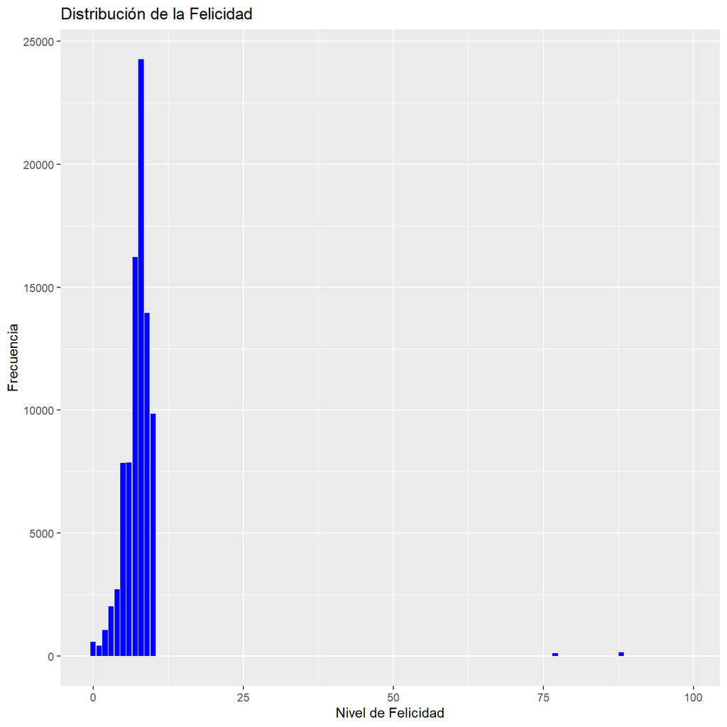

**Distribución de la Satisfacción con la vida**

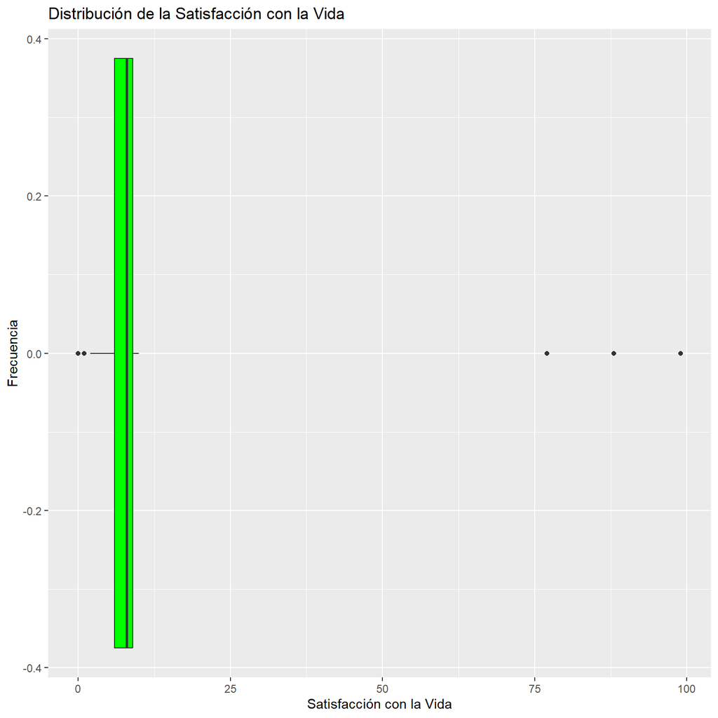

**Distribución de la Salud Subjetiva**

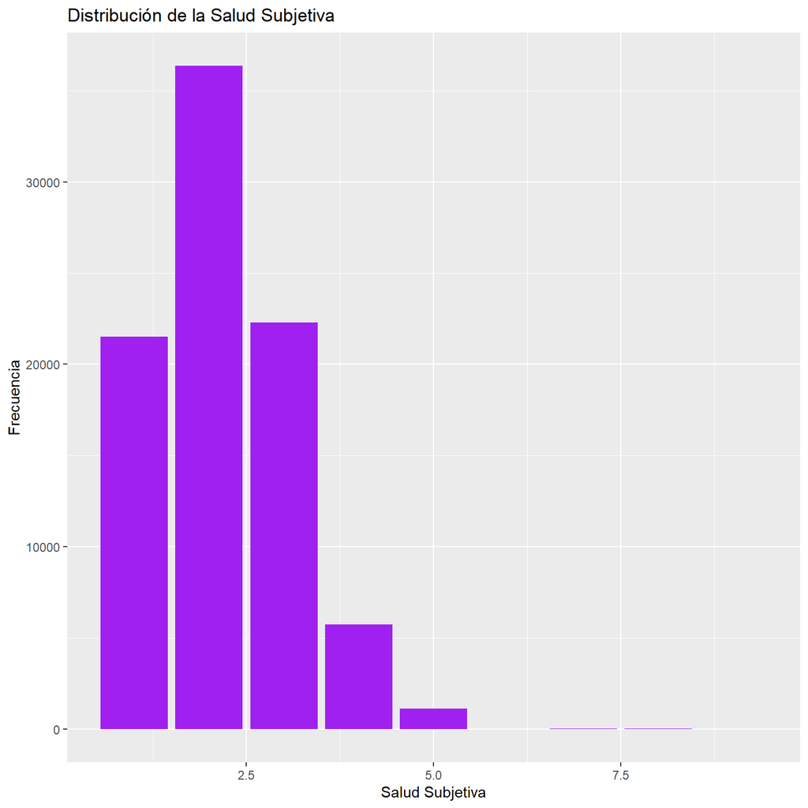

## 0.5 Gráficos Impacto de Factores Socioeconómicos

Se van a generar los siguientes gráficos: 1. Satisfacción con la Economía vs Satisfacción con la vida 2. Estado Civil y Satisfacción con la vida 3. Relación Laboral y Satisfacción con la vida

**Satisfacción con la Economía vs Satisfacción con la vida**

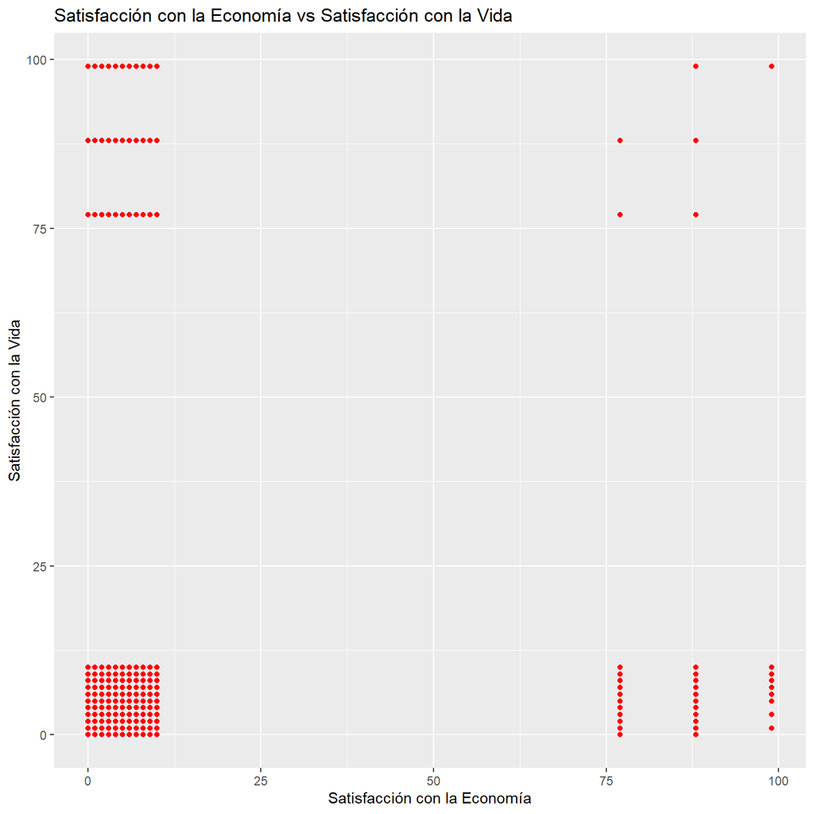

**Estado Civil y Satisfacción con la vida**

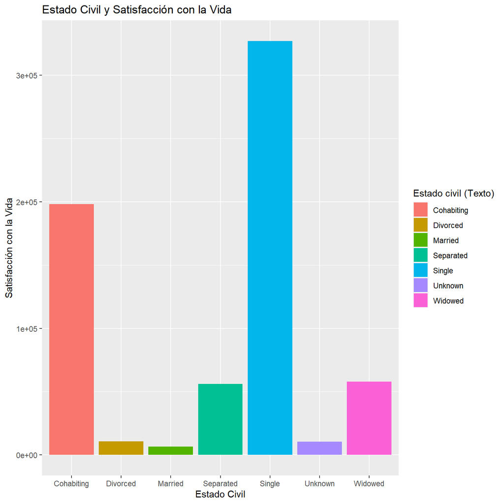

**Relación Laboral y Satisfacción con la vida**

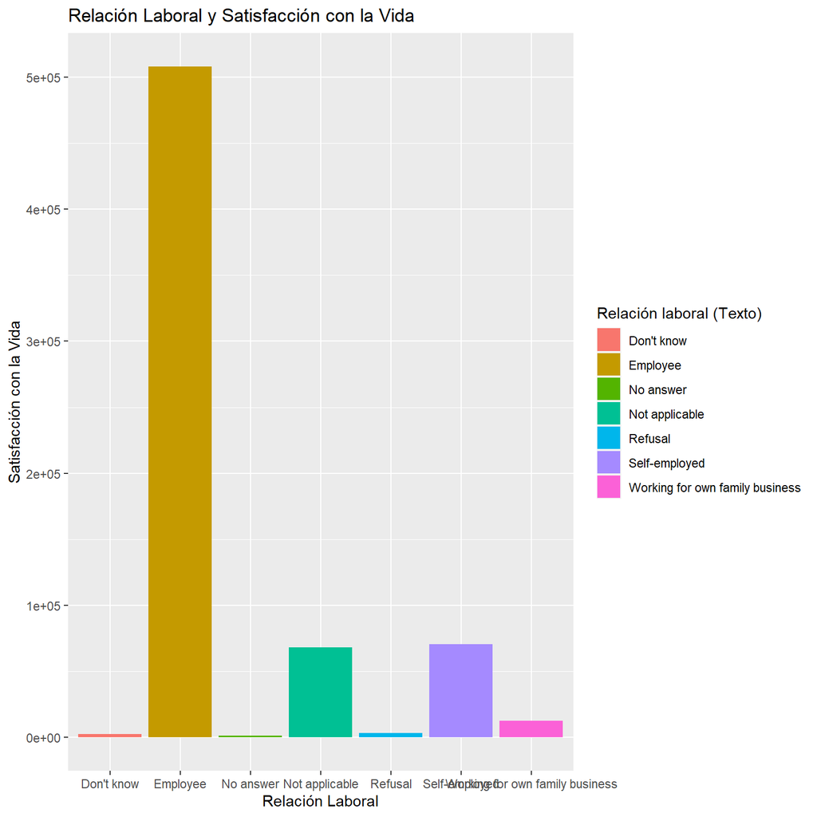

**Tiempo de uso de Internet vs nivel de felicidad**

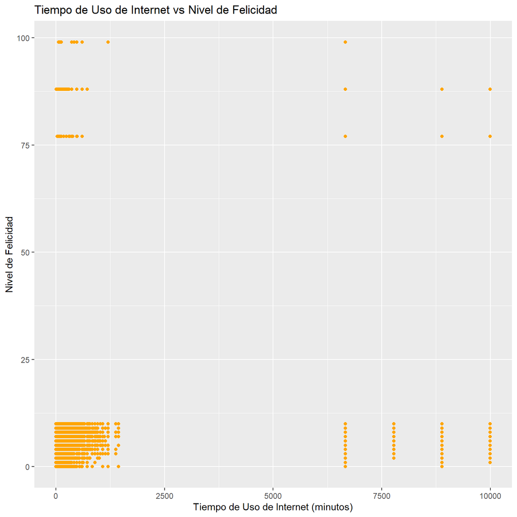

## 0.7 Gráficos para analizar la felicidad por Género y Educación

Se van a generar los siguientes gráficos: 1. Satisfacción con la vida por Género 2. Número de Encuestados por Grupo Educativo 3. Relación entre Nivel Educativo y satisfacción con la vida

**Satisfacción con la vida por Género**

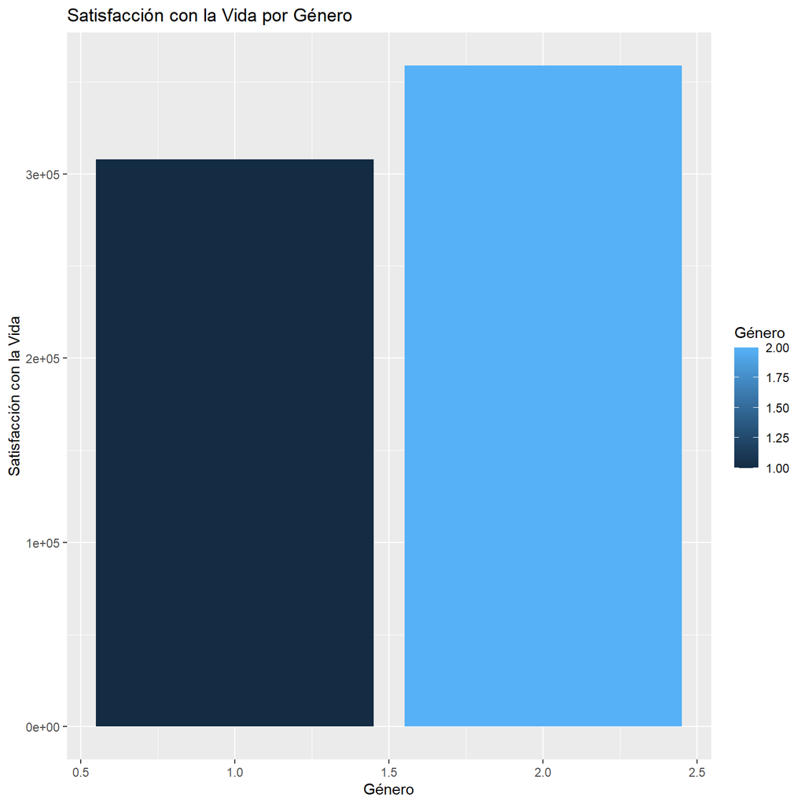

**Número de Encuestados por Grupo Educativo**

[figure not shown]

**Relación entre Nivel Educativo y satisfacción con la vida**

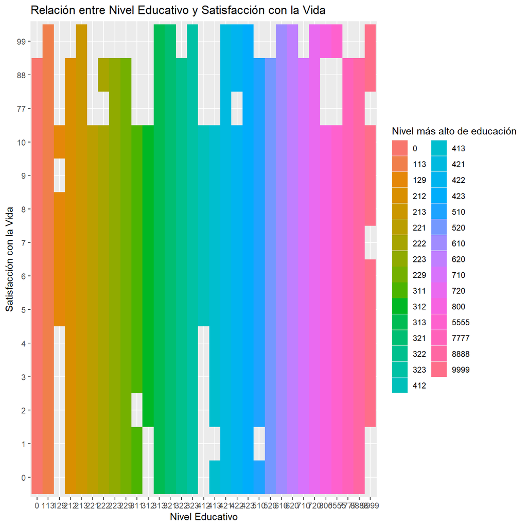

## 0.9 Referencias bibliográficas